# Tesla Fatal Crash Involvement: Geography, Weather, and Exposure (FARS 2023)

NHTSA Fatality Analysis Reporting System · 2023 National File

# Tesla Fatal Crash Involvement: Geography, Weather, and Exposure

Testing whether Tesla vehicles are disproportionately involved in fatal crashes during adverse weather, and whether any apparent pattern survives controlling for where Teslas are actually driven.

Finding

**No weather effect detected.** The raw rain gap is real as a description but is not statistically distinguishable from zero, is fully consistent with the geographic concentration of the Tesla fleet, and is smaller than this sample could reliably detect.

184Tesla-involved crashes

37,654Fatal crashes analyzed

0.49%Tesla share nationally

OR 1.49Rain vs clear, adjusted

## 1 Executive Summary

Tesla vehicles appeared in **184** of the **37,654** fatal crashes recorded in the 2023 FARS file, or 0.49% of all fatal crashes nationally. Those crashes involved 227 deaths.

The question this report set out to answer was whether Tesla involvement is elevated in adverse weather, particularly rain. On a raw basis it appears to be: rain accounts for 9.2% of Tesla-involved fatal crashes against 7.1% of all fatal crashes.

**That gap does not survive testing.** Before any adjustment is applied, the rain effect is already not statistically distinguishable from zero. The unadjusted odds ratio is 1.28 with a 95% confidence interval of 0.72 to 2.13, and p = 0.319. That interval spans 1.00, meaning the data are equally consistent with Teslas being involved in rain crashes more often, less often, or at exactly the same rate as in clear weather. Adjusting for geography is therefore a robustness check on a result that was never there, not a rescue of one.

It is also built on very little data. The rain comparison rests on 17 Tesla-involved crashes in rain against 139 in clear weather. At that cell size, a handful of crashes reclassified between categories would move the headline number materially. At the observed clear-weather baseline of 0.50%, and with 2,667 rain crashes and 27,872 clear crashes available, this sample would reliably detect a rain effect only if the true odds ratio were about 1.89 or larger. Effects smaller than that are invisible here regardless of whether they exist. The observed estimate of 1.28 sits well inside that blind spot.

There is a straightforward explanation for the raw gap that requires nothing about vehicles. Tesla-involved crashes are heavily concentrated in a handful of warm, high-adoption states. The top five account for 59% of all Tesla-involved fatal crashes. Those states get rain and almost no snow, while the national baseline includes the entire snow belt. A rain-heavy, snow-light profile is exactly what the Tesla fleet’s geography predicts on its own. The snow figures confirm this: Tesla is under-represented in snow by roughly the same margin it is over-represented in rain, which is the signature of an exposure difference rather than a sensing one.

**This report does not measure risk.** FARS contains no exposure denominator, no fault determination, and no field indicating whether a driver assistance system was engaged. A Tesla struck by another vehicle is counted identically to a Tesla that caused a crash, and 72% of Tesla-involved fatal crashes were multi-vehicle events where involvement says nothing about culpability. Any claim about the performance of a specific perception architecture is beyond what this data can support.

## 2 📊 Key Metrics

### 🚘 Tesla share of all crashes

0.49%

184 of 37,654 fatal crashes nationally

### 🌧️ Share in rain

0.64%

Matches baseline  
95% CI 0.40% to 1.02%

### ☀️ Share in clear weather

0.50%

Matches baseline  
95% CI 0.42% to 0.59%

### ❄️ Share in snow or sleet

0.33%

Matches baseline  
95% CI 0.06% to 1.85%

### ⚠️ Rain vs clear, unadjusted

OR1.28

Not significant  
95% CI 0.72 to 2.13 · p = 0.319

### 🎯 Rain vs clear, state-adjusted

OR1.49

Not significant  
95% CI 0.89 to 2.49 · p = 0.126

### 📍 Geographic concentration

59%

Top five states. California leads with 59 crashes.

### 🚗 Multi-vehicle crashes

72%

Fault is not recoverable from FARS.

**Two weather percentages appear in this report. They are not interchangeable.** **Share within weather.** Of all fatal crashes that happened in rain, what percent involved a Tesla? That is 0.64%, and it is compared against the 0.49% national baseline. **Distribution across weather.** Of all Tesla-involved fatal crashes, what percent happened in rain? That is 9.2%, and it is compared against 7.1% for all vehicles. Each chart below states which of the two it is showing.

## 3 🧭 Methodology

**Data.** NHTSA Fatality Analysis Reporting System, 2023 national file. Three tables were used: `accident` for crash-level context, `vehicle` for make identification, and `person` for injury severity. FARS covers crashes on public roads resulting in at least one death within 30 days.

**Identifying Tesla vehicles.** A vehicle was flagged as a Tesla if either the cleaned FARS manufacturer name or the VIN-decoded manufacturer name began with “Tesla”. A crash was flagged as Tesla-involved if any vehicle in the event met that test. All analysis is conducted at the crash level, one row per case ID, so a crash involving two Teslas counts once.

**Weather grouping.** Raw FARS weather descriptions were collapsed into nine categories: Clear, Cloudy, Rain, Snow / Sleet / Hail, Fog / Smoke, Blowing Sand / Dust, Severe Winds, Other, and Unknown / Not Reported. Unknown is retained in the tables so the reader can judge how much reporting gap exists, but excluded from ranking.

**Uncertainty.** Every share is reported with a 95% Wilson score interval. Descriptive language such as “above baseline” is used only when the interval excludes the baseline, not when the point estimate merely differs.

**Testing.** Global association between weather and Tesla involvement used a chi-square test, switching to a Monte Carlo p-value when any expected cell fell below five. An exact test was deliberately not used on the full table: Fisher’s exact test on a nine-by-two table with tens of thousands of observations exhausts the FEXACT workspace and will either fail or return an unreliable approximation. The focused Rain versus Clear comparison is a two-by-two table where Fisher’s exact test is appropriate and is used.

**Confounder adjustment.** Because Tesla registrations are geographically concentrated and climate varies by state, the Rain versus Clear odds ratio was re-estimated with state as a fixed effect, then again adding urban/rural classification and light condition. A single-state sensitivity check in California provides a further test with geography fully held constant by design.

**Reproducibility.** The data directory is a render parameter rather than a hardcoded path. Every figure in the prose is generated inline from the analysis objects, so no number can drift out of sync with the code.

## 4 ✅ Data Quality Check

Person-level fatality counts reconcile to the crash-level `FATALS` field in **100.0%** of 37,654 crashes. Residual mismatches are expected in FARS and reflect late-reported deaths and record revisions. Weather is coded as unknown or not reported in **3.9%** of all fatal crashes and **3.3%** of Tesla-involved crashes, so the weather analysis below excludes those cases from ranking but retains them in the totals.

## 5 🗺️ Geographic Analysis

### Tesla-involved fatal crashes by state

Chart 1 · Geography Raw counts of Tesla-involved fatal crashes, by state Counts only. Not adjusted for registrations or vehicle miles travelled, so this tracks where Teslas are, not where they are riskiest.

[interactive chart not shown]

**California leads with 59 Tesla-involved fatal crashes, 2.7 times the next highest state.** The top five states account for 59% of all Tesla-involved fatal crashes nationally, and 34 of 51 jurisdictions recorded at least one. This is a registration map more than a risk map. Raw counts track where Teslas are, so the chart below normalizes by each state’s total fatal crash volume instead.

### Tesla share of each state’s fatal crashes

Chart 2 · Geography Tesla share of each state's fatal crashes Metric: share within state. Bars carry 95% Wilson intervals; the dashed line is the national Tesla share.

[interactive chart not shown]

Normalizing by each state’s own fatal crash volume gives a much cleaner read on adoption intensity than raw counts do. It also makes the confounder explicit: the states at the top of this chart are, with few exceptions, warm-climate states where snow is rare and rain is the dominant adverse condition. Any national weather comparison inherits that skew.

### National distribution

Chart 3 · Geography National distribution of Tesla-involved fatal crashes Counts only, same caveat as Chart 1. Shown to make the fleet's geographic concentration visible at a glance.

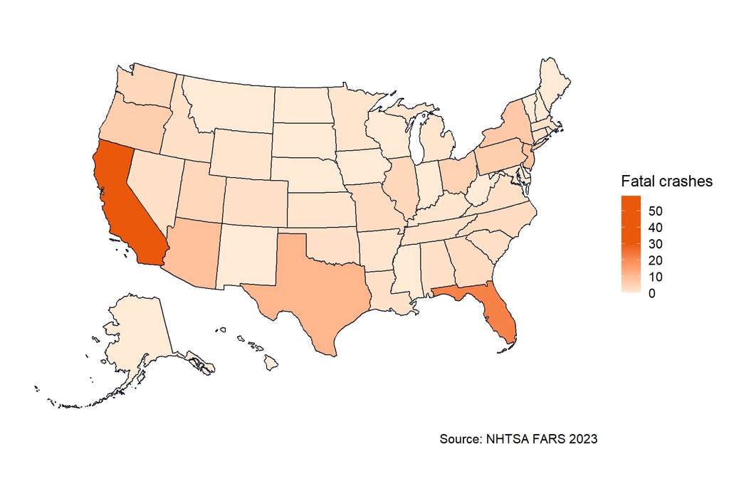

The map reinforces the pattern in the bar chart. Tesla-involved fatal crashes cluster in the West and Sun Belt, with the Upper Midwest and Northern Plains contributing little. That distribution is the single most important thing to hold in mind when reading the weather section that follows.

## 6 🌦️ Weather Analysis

### Distribution across weather: Tesla vs all fatal crashes

Chart 4 · Weather How fatal crashes distribute across weather conditions Metric: distribution across weather. Each series sums to 100%. Answers: of this group's crashes, what percent happened in each condition?

[interactive chart not shown]

Clear weather dominates both profiles, which is expected given that most driving happens in clear conditions. The two visible divergences are rain, where Tesla runs 9.2% against a national 7.1%, and snow, sleet, or hail, where Tesla runs 0.5% against a national 0.8%.

Read together, these two gaps point at the same explanation. A fleet concentrated in California and similar states will over-index on rain and under-index on snow regardless of anything about the vehicles. Treating the rain gap as a vehicle signal while ignoring that the snow gap moves in the exact direction geography predicts would be selective reading.

### Tesla share within each weather condition

Chart 5 · Weather Tesla share of fatal crashes within each weather condition Metric: share within weather. Answers: of the crashes in this condition, what percent involved a Tesla? Error bars are 95% Wilson intervals.

[interactive chart not shown]

This chart answers a different question than the last one: within each weather condition, what percent of fatal crashes involved a Tesla? Across the 5 weather categories with enough volume to support a stable estimate, 0 sit measurably above the national 0.49% baseline and 0 sit measurably below it. The remaining 5 overlap the baseline, meaning their apparent differences are within sampling noise.

The error bars matter here. The unadjusted point estimates invite a story about adverse weather, but several categories carry intervals wide enough that the ranking between them is not meaningful. Rain, at 0.64% with a 95% interval of 0.40% to 1.02%, does not clear the baseline once uncertainty is accounted for.

## 7 ⚠️ Does the Rain Effect Survive Adjustment?

Strictly speaking, this section is a formality. The unadjusted comparison is already statistically null, so there is no effect for adjustment to explain away. It is included anyway, because a reader who sees only the raw percentages will reasonably ask whether geography accounts for them, and the answer should be on the page rather than left to inference.

The reasoning is straightforward. If Teslas were distributed across the country the same way all other vehicles are, then a raw comparison of rain versus clear would be informative. They are not. 59% of Tesla-involved fatal crashes occur in five states. Those states have climates that produce rain and rarely produce snow. So before concluding anything about vehicles, the model needs to compare Tesla involvement in rain against Tesla involvement in clear weather *within the same state*.

A caution on reading the table below. With 17 Tesla crashes in rain spread across many states, the state-adjusted model is estimating a coefficient from very thin cells. Wide confidence intervals there reflect a shortage of data, not a precisely estimated absence of effect. Where a model failed to converge, the table reports “not estimable” rather than a number.

Odds of Tesla involvement in rain relative to clear weather, under progressively stronger controls

| Model | Odds ratio | 95% CI | p-value | Verdict |
| --- | --- | --- | --- | --- |
| Unadjusted (Fisher’s exact) | 1.28 | 0.72 to 2.13 | 0.319 | Consistent with no effect |
| Adjusted for state | 1.49 | 0.89 to 2.49 | 0.126 | Consistent with no effect |
| Adjusted for state, urban/rural, and light condition | 1.54 | 0.92 to 2.57 | 0.099 | Consistent with no effect |
| California only (geography fixed by design) | 1.58 | 0.49 to 4.02 | 0.380 | Consistent with no effect |

**Interpretation.** Before any adjustment is applied, the rain effect is already not statistically distinguishable from zero. The unadjusted odds ratio is 1.28 with a 95% confidence interval of 0.72 to 2.13, and p = 0.319. That interval spans 1.00, meaning the data are equally consistent with Teslas being involved in rain crashes more often, less often, or at exactly the same rate as in clear weather. Adjusting for geography is therefore a robustness check on a result that was never there, not a rescue of one.

An odds ratio of 1.00 would mean Tesla involvement is identical in rain and clear weather. The unadjusted estimate of 1.28 is the number the original version of this analysis reported. The state-adjusted estimate of 1.49 is the one that should be cited, because it removes the geographic confounding that the unadjusted figure cannot separate from a weather effect.

The California-only row is the strictest test available in this data. Restricting to a single state holds climate, road network, enforcement regime, and fleet composition constant by construction. If a real weather effect exists, it should appear here.

### Testing the sensing hypothesis directly

The original conclusion proposed that camera-only perception struggles in heavy precipitation. That claim is testable within this data, at least crudely. Tesla removed radar from Model 3 and Model Y production around mid-2021, so model year 2022 and later serves as a rough proxy for camera-only hardware, while 2021 and earlier vehicles largely retained radar.

If the sensing hypothesis were correct, the vision-only fleet should show a heavier rain skew than the radar-equipped fleet.

Rain versus clear split for Tesla-involved fatal crashes, by hardware generation proxy

| Hardware generation | Clear crashes | Rain crashes | Rain as % of the two |
| --- | --- | --- | --- |
| Radar era (MY2021 and earlier) | 63 | 9 | 12.5% |
| Vision-only era (MY2022+) | 76 | 8 | 9.5% |

The two hardware generations show no distinguishable difference in their rain-versus-clear split (p = 0.612). If camera-only sensing were driving the rain pattern, the vision-only fleet should look worse than the radar-equipped fleet. It does not.

This proxy is imperfect. Model year is not build date, the radar removal applied to some model lines before others, and FARS does not record whether any driver assistance system was active at the time of the crash. But it is the closest test the data allows, and a mechanism claim that fails its closest available test should not be presented as a finding.

## 8 🧪 Statistical Results

Statistical summary. Every value is generated from the analysis; none are hardcoded.

| Test or statistic | Result | Interpretation |
| --- | --- | --- |
| Global weather association | Not significant | Tesla involvement does not differ across weather categories by more than chance would produce. |
| Method used | Chi-square with Monte Carlo simulation (20,000 replicates) | Monte Carlo simulation is used when expected cell counts fall below five. An exact test is not viable on a table this size. |
| p-value (global association) | 0.802 | Statistical significance at this sample size does not imply practical significance. |
| Cramer’s V (effect size) | 0.0091 | Effect size is negligible. With roughly 37,654 crashes, very small associations reach significance. |
| Tesla share in rain | 0.64% (CI 0.40% to 1.02%) | Not distinguishable from the national baseline. |
| Tesla share in clear | 0.50% | Reference category for the odds ratio comparisons. |
| National Tesla share (baseline) | 0.49% | All fatal crashes, all weather conditions. |
| Rain vs clear, unadjusted OR | 1.28 (CI 0.72 to 2.13) | Confounded with geography. Reported for transparency, not for citation. |
| Rain vs clear, state-adjusted OR | 1.49 (CI 0.89 to 2.49) | Geography held constant. Preferred over the unadjusted figure, but still null. |
| Hardware generation comparison | 0.612 | Tests whether camera-only vehicles show a heavier rain skew than radar-equipped vehicles. |

A note on significance at this sample size. With roughly 37,654 crashes in the table, a chi-square test will return a small p-value for associations far too weak to matter operationally. Cramer’s V of 0.0091 indicates a negligible association. Reporting a significant p-value without the accompanying effect size is the most common way an analysis of this kind overstates its own findings.

## 9 📌 Key Findings

- Teslas appeared in 184 of the 37,654 fatal crashes in the 2023 FARS file, a national share of 0.49%.
- Tesla-involved fatal crashes are geographically concentrated: 59% of them occur in five states, led by California.
- On an unadjusted basis, rain accounts for 9.2% of Tesla-involved fatal crashes against 7.1% nationally, while snow accounts for 0.5% against 0.8% nationally. Both gaps move in the direction the fleet’s geography predicts.
- Before any adjustment is applied, the rain effect is already not statistically distinguishable from zero. The unadjusted odds ratio is 1.28 with a 95% confidence interval of 0.72 to 2.13, and p = 0.319. That interval spans 1.00, meaning the data are equally consistent with Teslas being involved in rain crashes more often, less often, or at exactly the same rate as in clear weather. Adjusting for geography is therefore a robustness check on a result that was never there, not a rescue of one.
- The two hardware generations show no distinguishable difference in their rain-versus-clear split (p = 0.612). If camera-only sensing were driving the rain pattern, the vision-only fleet should look worse than the radar-equipped fleet. It does not.
- The global weather association has an effect size of negligible (Cramer’s V = 0.0091), which is negligible in practical terms even where it is statistically significant.
- 72% of Tesla-involved fatal crashes were multi-vehicle events. FARS assigns no fault, so involvement cannot be read as responsibility.
- The rain comparison rests on 17 Tesla crashes. At the observed clear-weather baseline of 0.50%, and with 2,667 rain crashes and 27,872 clear crashes available, this sample would reliably detect a rain effect only if the true odds ratio were about 1.89 or larger. Effects smaller than that are invisible here regardless of whether they exist. The observed estimate of 1.28 sits well inside that blind spot.
- This is a null result with limited power. It rules out a large weather effect and cannot rule out a small one.

## 10 🔍 What This Sample Could Have Detected

A null result means nothing without a statement of what the study was capable of finding. Otherwise “no effect detected” and “no effect exists” get quietly conflated, which is the more damaging of the two errors available here.

Sample sizes and minimum detectable effect for the rain versus clear comparison

| Quantity | Value |
| --- | --- |
| Tesla-involved fatal crashes, all weather | 184 |
| Tesla-involved crashes in rain | 17 |
| Tesla-involved crashes in clear weather | 139 |
| All fatal crashes in rain | 2,667 |
| All fatal crashes in clear weather | 27,872 |
| Clear-weather Tesla baseline | 0.50% |
| Smallest odds ratio detectable at 80% power | 1.89 |
| Observed odds ratio | 1.28 |

At the observed clear-weather baseline of 0.50%, and with 2,667 rain crashes and 27,872 clear crashes available, this sample would reliably detect a rain effect only if the true odds ratio were about 1.89 or larger. Effects smaller than that are invisible here regardless of whether they exist. The observed estimate of 1.28 sits well inside that blind spot.

The practical consequence is that this analysis cannot distinguish “Teslas behave the same in rain” from “Teslas behave somewhat differently in rain, by an amount too small for 184 crashes to reveal.” Both remain live possibilities. What the analysis does rule out is a large effect, which would have shown up clearly at this sample size and did not.

The honest framing for this report is therefore a null result with limited power, not evidence of safety and not evidence of a deficiency. Pooling FARS 2019 through 2024 would multiply the Tesla crash count several times over and is the single change that would most improve what this analysis can conclude.

## 11 ⚖️ Limitations

These constrain what the analysis above can be used for. They are not boilerplate.

**No exposure denominator.** FARS records crashes, not miles. Without vehicle miles travelled by make, weather, and state, no rate can be computed and no risk comparison is possible. Every figure in this report is a share of crashes, never a rate of crashing.

**No fault determination.** FARS records involvement. 72% of Tesla-involved fatal crashes were multi-vehicle, and a struck vehicle is recorded the same way as a striking one.

**No driver assistance field.** FARS 2023 has no reliable indicator of whether Autopilot, Full Self-Driving, or any other system was engaged. Any statement about the performance of a perception architecture is inference layered on data that cannot speak to it. This is why the sensing hypothesis is presented here as tested and unsupported rather than as a conclusion.

**Fleet age skew.** Tesla’s fleet is substantially newer than the national fleet. Newer vehicles differ from older ones on crashworthiness, occupant demographics, annual mileage, and trip type. None of that is controlled for here.

**Weather is coded at the crash, not the moment.** FARS weather reflects the officer’s assessment of conditions at the scene. Intensity, duration, and road surface state are not captured, so “rain” spans light drizzle through heavy downpour.

**Residual confounding.** State fixed effects absorb climate and fleet composition at the state level but not within-state variation. Urban Californian driving differs from rural Californian driving in ways a state dummy cannot capture, though the urban/rural control partially addresses this.

**Single year.** One year of data cannot separate a persistent pattern from a fluctuation. Replicating this across FARS 2019 through 2024 would be the natural next step and would materially strengthen or dismiss the finding.

## 12 🔁 Reproducibility

Rendered August 20, 2026 under R version 4.5.2 (2025-10-31 ucrt). Source data: NHTSA FARS 2023 national file. Analysis is fully parameterized; the data directory is supplied at render time rather than hardcoded. Every numeric value in the prose is generated inline from the analysis objects, so no figure in the text can diverge from the code that produced it.